# Urban Terror

Thursday, December 04, 2014

## Origins

[figure not shown]

## Research Question

**Do terrorists target urban environments more now than in past days?**  
> Purely descriptive analysis of a change of time in terrorists targeting behavior

## Data Collection

## Main Database

- [Open Source Database](http://www.start.umd.edu/gtd/) run by University of Maryland
- contains more than 120,000 observations on over 120 variables between 1970 and 2013
- detailed description of target and effect of attack
  - target & weapon,
  - human & property damage
  - perpetrator

The GTD is a powerful database!

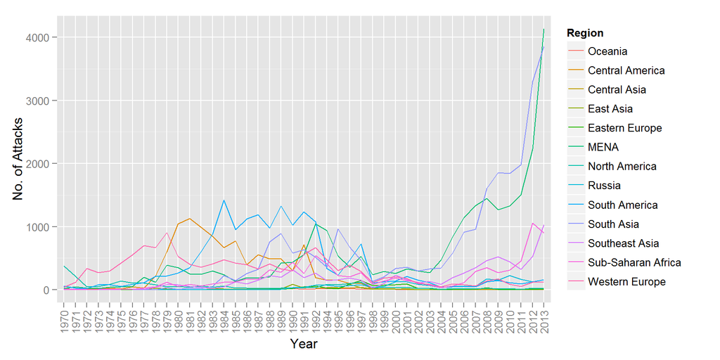

**Figure 1:** attacks per year in all world regions

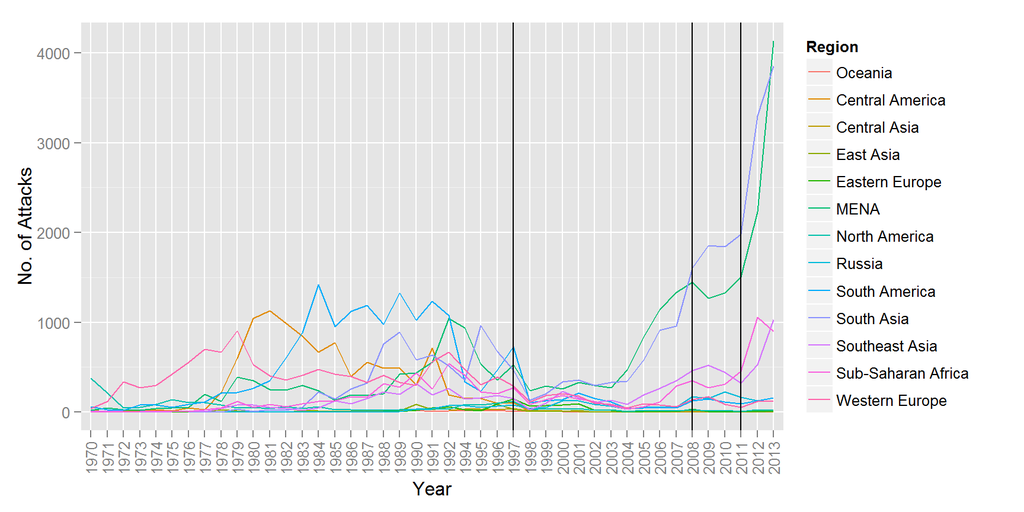

**Figure 2:** attacks per year in all world regions, indicating transition of collectors: PGIS - 1997, CETIS - 2008, ISVG - 2011, START since 2011

## Main Database

- improvable data quality
- a lot of information is missing  
  The GTD is not providing enough information to answer our research question

## Main Database

- Target's potential urbanity is provided
- Environment's is not
  - Location (suburb? center?)
  - Importance (capital? stronghold?)
  - `Urbanity`

[figure not shown]

## Addtional Databases

We use absolute and relative city size (population) as a proxy for urbanity.

- City level data
  - [about 45,000 cities from the R 'maps' package](http://CRAN.R-project.org/package=maps)
  - [about 48,000 cities from Maxmind Inc.](http://download.maxmind.com/download/geoip/database/LICENSE_WC.txt)
  - [additonal 110,000 cities from geonames.com](http://www.geonames.org/)
  - [458 urban centers from wikipedia](http://en.wikipedia.org/wiki/List_of_urban_areas_by_population)
- Country level data
  - [World Development Indicators from the World Bank](http://data.worldbank.org/data-catalog/world-development-indicators)
  - [Correlates of War from the COW project](http://www.correlatesofwar.org/)

## Limitations

- `Validity`
  - population an insufficient proxy for urbanity
  - but economic, political etc. data not available open source on city level
  - and population probably the single most important one
- `Reliability`
  - multiple collection sources over decades with unreproducible methods in unclear administrative environments

## Data Cleaning

## Challenges

Within single and across datasets

Issue

Example

Detail

Solution

Inconsistency

Spellings

- "Congo, Kinshasa"
- "Congo, Dem. Rep."
- RegEx
- Hand Coding

Quality

Typos

Errors

- "Agfhanistan" vs.

"Arabistan"

- RegEx
- Hand Coding

Bias

Underreportings

Definitions

- Soviet Union: 67 vs. Russia: >1200
- Iraq since 2003 vs. Afghanistan 79-89
- Control Variables

## Hand Coding

- Adjusting City and Country Names

  ```
  X<-gsub("^Teberan","Tehran", X, ignore.case=TRUE)
  X<-gsub("^Teheran","Tehran", X, ignore.case=TRUE)
  X<-gsub("^Teherau","Tehran", X, ignore.case=TRUE)
  X<-gsub("^Tehram","Tehran", X, ignore.case=TRUE)
  ```

- "Reassigning" Cities to Countries

  ```
  GTD$country_txt[GTD$country_txt == "Soviet Union" &
                  GTD$city =="Osh" ] <- "Kyrgyzstan"
  GTD$country_txt[GTD$country_txt == "Soviet Union" &
                  GTD$city =="Riga" ] <- "Latvia"
  GTD$country_txt[GTD$country_txt == "Yugoslavia" &
                  GTD$city =="Bogicevica" ] <- "Albania"
  GTD$country_txt[GTD$country_txt == "Yugoslavia" &
                  GTD$city =="Banjica" ] <- "Serbia"
  ```

## Data Manipulating

## Filling, Adding, Extrapolating

- `Geo Referencing` absolute & relative city position
- `Proximity Referencing` each city by assigning it to its closest Urban Center
- Establishing `Relative City Size` as a share of each countries' largest cityies'total population
- Estimating `Past Populations` using country level data and growth rates
- Determining `Cities' Rank` Size given by the population on a country, regional, and world level
- Including additional `Control Variables` for capitals, largest cities, inter-state war, intra-state war, extra-in war, extra-out war, and coastal megacities

[figure not shown]

## Merging to Current Dataset

We merge city level, country level, and GTD data together to a reproducible database containing 114086 observations on 44 variables.

- Merged database contains NA share of 11%
- Considered acceptable
- Potential for further reduction
- We assume systematic sources

## Data Analysis

## Approach

We use a simple linear regression, depending on Relative City Sizes attacked over time for various world regions. We control for

- Extra-In State War
- Extra-Out State War
- Intra State War
- Inter State War
- Capitals
- Target's Potential Urbanity
- including weightings for human and property damage

## Results

[Regresison Table](https://www.dropbox.com/s/tm9ay9dh7o4izyx/rank.model.per.region.1998bis2013.INTRA.WAR.TEST.html?dl=0)

- There is no general global trend for terrorists moving to urban targets
- Results vary across world regions:
  - there is a trend in the Arab World
  - there is a trend in Southeast Asia
- Civil War changes everything!

## From Here…

| # | City | Country | Attacks (Peace) |
| --- | --- | --- | --- |
| 1 | Santiago | Chile | 1426 |
| 2 | Belfast | United Kingdom | 1187 |
| 3 | Karachi | Pakistan | 1155 |
| 4 | Bogota | Colombia | 845 |
| 5 | Medellin | Colombia | 808 |

#

Region

Attacks

1

S. Asia

```
 25854
```

2

MENA

```
 25250
```

3

S. America

```
 16917
```

4

W. Europe

```
 13217
```

5

C. America

```
 10158
```

Human Damage

City

Country

Killed+Injured

1

Baghdad

```
 Iraq
```

```
  4345
```

2

```
Lima
```

```
 Peru
```

```
  2163
```

3

Karachi

Pakistan

```
  1879
```

4

Belfast

United Kingdom

```
  1706
```

5

San Salvador

El Salvador

```
  1491
```

#

Group

Country

Total Attacks

1

Shining Path

```
 Peru
```

```
  4533
```

2

FMNLF

El Salvador

```
  3351
```

3

Taliban

Afghanistan

```
  3204
```

4

```
IRA
```

United Kingdom

```
  2673
```

5

```
FARC
```

Colombia

```
  2228
```

## Outlook

- Still a lot of potential for further cleaning
- More possibilities for including control variables
- Currently only few projects using GTD for analysis
- Our approach seems promising for more research endavours
- `First, the Master's Thesis!`

## References

Cutter, Susan, Douglas B Richardson, and Thomas J Wilbanks. 2003. *The Geographical Dimensions of Terrorism*. Routledge.

Kilcullen, David. 2013. *Out of the Mountains: the coming age of the urban guerrilla*. Oxford University Press.

START. 2013. *Global Terrorism Database \(GTD\)*. Maryland: National Consortium for the Study of Terrorism; Responses to Terrorism. http://www.start.umd.edu/gtd.